# Analysis of Variance

ANOVA Tables

Ranadeep Daw

2024-11-14

## Analysis of Variance

- You have already seen one example of analysis of variance.
- Recall the linear regression problem:

$$y_i =
\beta_0 + \beta_1 X_{1i} + \beta_2 X_{2i} + \ldots + \beta_p X_{pi} +
\epsilon_i$$

- We want to explain the total sum of squares (SST) = $\sum_{i=1}^n (y_i - \bar{y})^2$ in the response variable $y$.

## Analysis of Variance

- We use the linear regression model to predict as:

$$\hat{y}_i =
\widehat{\beta}_0 + \widehat{\beta}_1 X_{1i} + \widehat{\beta}_2 X_{2i}
+ \ldots + \widehat{\beta}_p X_{pi}$$

- We defined two quantities:
  - Sum of squares of error (SSE) = $\sum_{i=1}^n (y_i - \hat{y}_i)^2$
  - Regression sum of squares (RSS) = $\sum_{i=1}^n (\hat{y}_i - \bar{y})^2$.
- **RSS** is what we can explain through the model.
- **SSE** is what we can not explain.

## Model Significance Test

- If there are $n$ subjects and $p$ predictors in the regression model, SSE has a degrees of freedom $n-p-1$.
- Given $n$ subjects, SST has a degrees of freedom $n-1$.
- The remaining $p$ degrees of freedom is correspoding to RSS.
- We discussed the model significance test: $H_0: \beta_1 = \ldots = \beta_p = 0$; $H_A$: At least one coefficient is not $0.$

## Model Significance Test (cont.)

- We use the $F$ statistic is given by:

$$\text{F} =
\frac{\frac{\text{RSS}}{p}}{\frac{\text{SSE}}{n-p-1}}$$

- Under $H_0$, F is distributed as a $F$ distribution with degrees of freedoms $p$ and $n-p-1$.
- We reject $H_0$ at level $\alpha$ if F > $F_{\alpha; p, n-p-1}$ (or if the $p$ value < $\alpha).$

## Example

- As an example, let’s again use the $\texttt{mtcars}$ data using the $\texttt{mpg}$ as the dependent variable, and $\texttt{disp}$ as the independent variable.

```r
data("mtcars")
mpg_model = lm( mpg ~ disp, data = mtcars )
mpg_model
```

```
##
## Call:
## lm(formula = mpg ~ disp, data = mtcars)
##
## Coefficients:
## (Intercept)         disp
##    29.59985     -0.04122
```

## Example

```r
summary(mpg_model)
```

```
##
## Call:
## lm(formula = mpg ~ disp, data = mtcars)
##
## Residuals:
##     Min      1Q  Median      3Q     Max
## -4.8922 -2.2022 -0.9631  1.6272  7.2305
##
## Coefficients:
##              Estimate Std. Error t value Pr(>|t|)
## (Intercept) 29.599855   1.229720  24.070  < 2e-16 ***
## disp        -0.041215   0.004712  -8.747 9.38e-10 ***
## ---
## Signif. codes:  0 '***' 0.001 '**' 0.01 '*' 0.05 '.' 0.1 ' ' 1
##
## Residual standard error: 3.251 on 30 degrees of freedom
## Multiple R-squared:  0.7183, Adjusted R-squared:  0.709
## F-statistic: 76.51 on 1 and 30 DF,  p-value: 9.38e-10
```

## ANOVA Table

- In this lecture, we will print the details of the $F$ test in the ANOVA(**AN**alysis **O**f **VA**riance) table and will be of the following format:

| Source | Df | Sum Sq | Mean Sq | F value |
| --- | --- | --- | --- | --- |
| Predictor 1 | *$df_1$* | *SS1* | *MS1* = $\frac{SS1}{df_1}$ | *F1* = $\frac{MS1}{MSE}$ |
| Predictor 2 | *$df_2$* | *SS2* | *MS2* = $\frac{SS2}{df_2}$ | *F2* = $\frac{MS2}{MSE}$ |
| $\vdots$ | $\vdots$ | $\vdots$ | $\vdots$ | $\vdots$ |
| Residuals | *$df_E$* | *SSE* | *MSE* = $\frac{SSE}{df_E}$ |  |

## ANOVA Table Example in $\texttt{R}$

```r
summary.aov(mpg_model)
```

```
##             Df Sum Sq Mean Sq F value   Pr(>F)
## disp         1  808.9   808.9   76.51 9.38e-10 ***
## Residuals   30  317.2    10.6
## ---
## Signif. codes:  0 '***' 0.001 '**' 0.01 '*' 0.05 '.' 0.1 ' ' 1
```

- Also shows you the $p$ value of the ANOVA table.
- Whenever $p$ value < $\alpha$, the corresponding predictor is **significant**.
- This also shows that in the regression model, the predictor variable has a significance in predicting the response. It’s not meaningless or removable from the model.

## Categorical Variables

- Before the next part, we need to define categorical variables – a variable that can only realize a few categories.
- You already saw an example of this – binary resonse variable:
  - A variable that can realize only two categories - Yes/No; 1/0; Head/Tail.

## Categorical Variables (Cont.)

- To generalize further, a categorical variable can observe $k$ different categories: Level $1$, …, level $k$.
  - **Example 1**: Customer satisfaction levels taking **$5$** possible categories –  
    1. Very dissatisfied,  
    2. Dissatisfied,  
    3. Neutral,  
    4. Satisfied,  
    5. Very satisfied.
  - **Example 2**: A multiple choice question with possible answers Yes/No/Maybe.

## ANOVA for Categorical Predictors

- ANOVA tables become more interesting with categorical predictor variables.
- One may be interested in knowing how different categories of a predictor can affect the response differently.
- For example, one may divide a set of patients into two groups – treatment and placebo. We want to know if the treatment works better than the placebo.
- In this case, we typically use the terminology *treatment* to denote the levels of the predictor variables.

## Example: `sleep` data

- Example: In $\texttt{R}$, the `sleep` data has three variables – `extra` as the response variable ($y$), and `group` as the predictor variable ($x$). `ID` variable are patient IDs.
- The `extra` variable shows the effect of two drugs on increase in hours of sleep.
- The `group` variable is categorical and has two levels - `1` and `2`.

## Example: `sleep` data

```r
data("sleep")
sleep
```

```
##    extra group ID
## 1    0.7     1  1
## 2   -1.6     1  2
## 3   -0.2     1  3
## 4   -1.2     1  4
## 5   -0.1     1  5
## 6    3.4     1  6
## 7    3.7     1  7
## 8    0.8     1  8
## 9    0.0     1  9
## 10   2.0     1 10
## 11   1.9     2  1
## 12   0.8     2  2
## 13   1.1     2  3
## 14   0.1     2  4
## 15  -0.1     2  5
## 16   4.4     2  6
## 17   5.5     2  7
## 18   1.6     2  8
## 19   4.6     2  9
## 20   3.4     2 10
```

## Example: `sleep` data

- Here, the question of interest is that if there is a difference in the effect of the two drugs on the response: `extra`.
- Careful! We want to check the **difference** only, not the absolute effect of a drug on the response.
- We can now build a regression model with `extra` as response and `group` as predictor first.
- Then, we can build the ANOVA table to formally test our question of interest.

## ANOVA Table for Categorical Data

- Define $\mu_k$: the mean effect of the predictor when at level $k$.
- So in this example, $\mu_1$ is the mean effect of drug 1 on the patients on the response variable `extra`.
- $\mu_2$ is the mean effect of drug 2.
- Here, we will be interested in fitting the regression model:

$$y_{ij} = \mu_i +
\epsilon_{ij}$$

where $i= 1,2$; $j = 1, \ldots, n_i$.

## ANOVA F Test Hypothesis

- If the two drugs (1 and 2) have the similar effect on the response variable, we can simplify the above model as:
  $$y_{ij} = \mu + \epsilon_{ij}$$
- When a predictor at all it’s different levels has the exact same effect on the response variable, there is no significance of the predictor in the regression model.
- Therefore, in this regression model, we would be interested in testing the significance of the predictor `group` by testing the following hypothesis: $H_0: \mu_1 = \mu_2$, $H_A: \mu_1 \neq \mu_2.$

## Example with `sleep` data

- Let’s try to visualize first if the `group` variable has any effect on the response variable `extra`.
- Plot the predictor level-wise boxplot of the response variable to see how the response variable behaves against the predictor variables different levels, or against different treatment effects.

## Example with `sleep` data

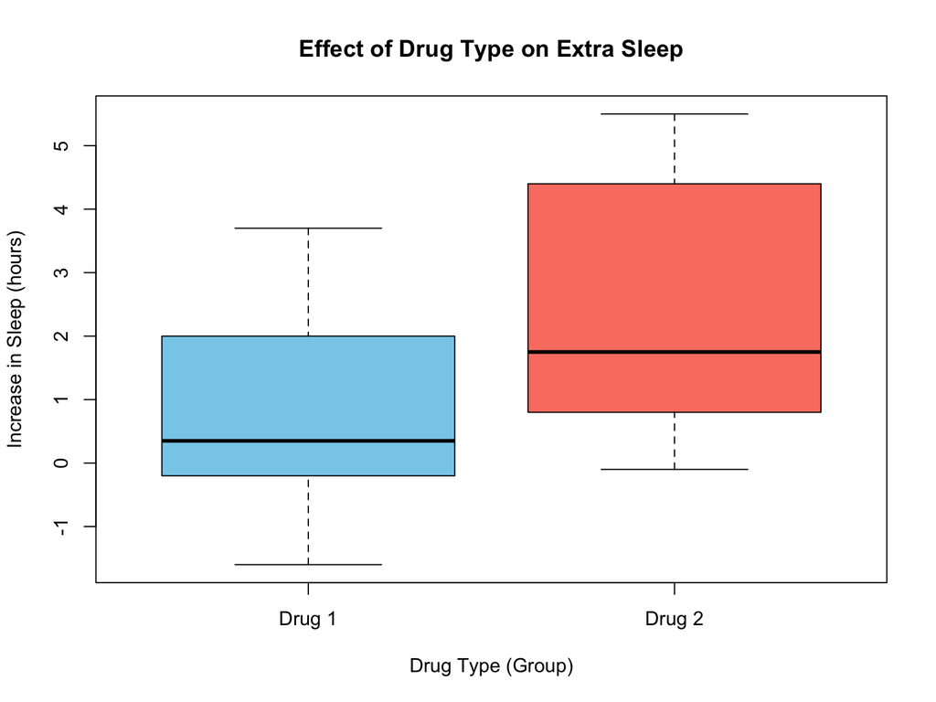

```r
boxplot(extra ~ group, data = sleep,
        main = "Effect of Drug Type on Extra Sleep",
        xlab = "Drug Type (Group)", ylab = "Increase in Sleep (hours)",
        col = c("skyblue", "salmon"), names = c("Drug 1", "Drug 2"))
```

## Example with `sleep` data

- Look at the `boxplot`. The overall pattern is that the drug 2 improves the sleep hour (`extra` or $y$) better than drug 1.
- But, can we prove that, statistically, the predictor `group` has a significant effect on the response `extra`? (i.e., is $\mu_1 \neq \mu_2$?)
- Let’s do the formal test in $\texttt{R}$ : $H_0: \mu_1 = \mu_2, H_A: \mu_1 \neq \mu_2.$

## Example with `sleep` data

```r
data("sleep")
sleep_model = lm( extra ~ group, data = sleep)
summary.aov(sleep_model)
```

```
##             Df Sum Sq Mean Sq F value Pr(>F)
## group        1  12.48  12.482   3.463 0.0792 .
## Residuals   18  64.89   3.605
## ---
## Signif. codes:  0 '***' 0.001 '**' 0.01 '*' 0.05 '.' 0.1 ' ' 1
```

## Example with `sleep` data

- Look at the $p$ value.
- Only when a $p$ value is less than our typical significance level of $0.05$, the predictor becomes significant.
- Otherwise, can’t reject $H_0$: $\mu_1 = \mu_2$.
- Hence, here, the predictor is not statistically significant.

## Check with Regression Problem

- Look at the summary of the regression model:

```r
summary(sleep_model)
```

```
##
## Call:
## lm(formula = extra ~ group, data = sleep)
##
## Residuals:
##    Min     1Q Median     3Q    Max
## -2.430 -1.305 -0.580  1.455  3.170
##
## Coefficients:
##             Estimate Std. Error t value Pr(>|t|)
## (Intercept)   0.7500     0.6004   1.249   0.2276
## group2        1.5800     0.8491   1.861   0.0792 .
## ---
## Signif. codes:  0 '***' 0.001 '**' 0.01 '*' 0.05 '.' 0.1 ' ' 1
##
## Residual standard error: 1.899 on 18 degrees of freedom
## Multiple R-squared:  0.1613, Adjusted R-squared:  0.1147
## F-statistic: 3.463 on 1 and 18 DF,  p-value: 0.07919
```

- See that the model is not significant, i.e., $p$ value > $\alpha$.

## Generalized ANOVA with Categorical Data

- Now, it’s time to extend the theory for general predictor variables with $k$ levels.
- Consider a regression problem with response $y$ and a predictor variable with $k$ levels.
- Consider that the $k$-th level has an effect $\mu_k$ on the response.
- Then, the regression model can be rewritten as:

$$y_{ij} = \mu_i +
\epsilon_{ij}$$

where $i=1, 2, \ldots, k$; $j= 1,\ldots, n_i$.

## ANOVA with Categorical Data

- First define: $\bar{y}_i = \frac{1}{n_i}\sum_{j=1}^{n_i} y_{ij}, \bar{y} = \frac{1}{n}\sum_{1}^{n_i}\sum_{j=1}^{n_i} y_{ij}$.
- Define the following:
  - **Total Sum of Squares**: $\text{SST} = \sum_{i=1}^k \sum_{j=1}^{n_i} (y_{ij} - \bar{y})^2.$
  - **Regression Sum of Squares**: $\text{RSS} = \sum_{i=1}^k n_i (\bar{y}_i - \bar{y})^2.$
  - **Sum of Squared Errors**: $\text{SSE} = \sum_{i=1}^k \sum_{j=1}^{n_i} (y_{ij} - \bar{y}_i)^2.$
- Note: TSS = RSS + SSE.

## ANOVA: F test

- $H_0$: $\mu_1 = \ldots = \mu_k$; $H_A$: At least one effect is different.
- F statistic = $\frac{\frac{RSS}{k-1}}{\frac{SSE}{n-k}}.$
- Reject $H_0$ if F > $F_{\alpha; k-1, n-k}$ or if the associated $p$ value < $\alpha$.

## Example 2: `InsectSprays` data in `R`

- The `InsectSprays` data contains $n=72$ observations of insects in agricultural experimental units treated with different insecticides.
- It has two variables – response variable (or $y$) is the variable `count`, and the predictor variable (or $x$) is named as `spray`.
- The predictor variable `spray` has $k=6$ levels- A, B, C, D, E, F.
- So, $df_T$ = 72-1 = 71, $df_R$ = 6-1 = 5, $df_E$ = $72-6$ = 66.

## Example 2: `InsectSprays` data

- First, visualize the effect of `spray` on `count`.

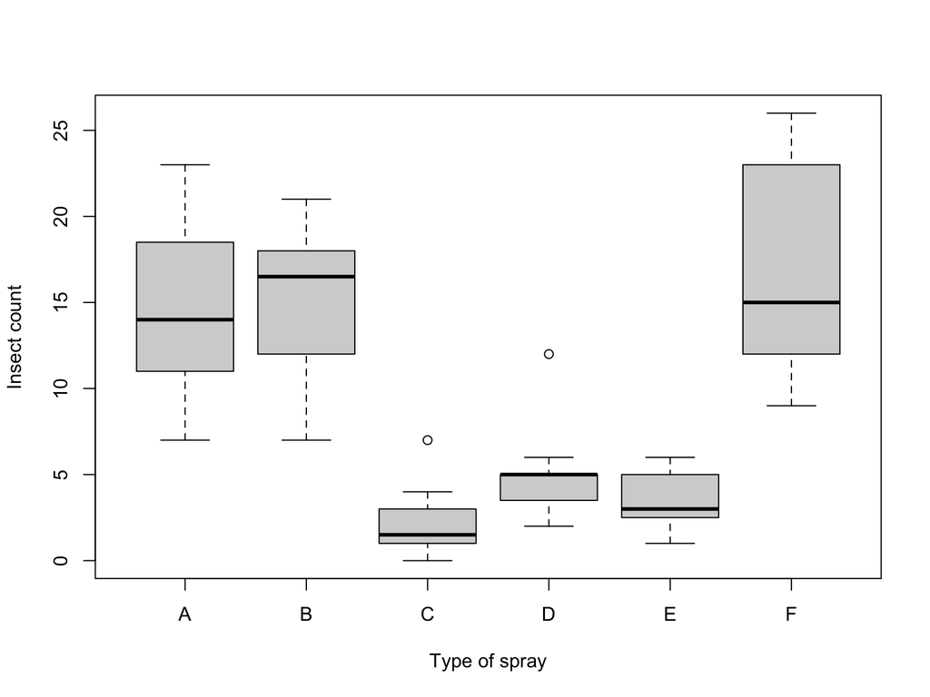

```r
data("InsectSprays") # Don't do this step in Homework
boxplot(count ~ spray, data = InsectSprays,
        xlab = "Type of spray", ylab = "Insect count")
```

## Example 2: `InsectSprays` data

- Let’s build the ANOVA table in `R`.

```r
spray_model = lm( count ~ spray, data = InsectSprays )
summary.aov(spray_model)
```

```
##             Df Sum Sq Mean Sq F value Pr(>F)
## spray        5   2669   533.8    34.7 <2e-16 ***
## Residuals   66   1015    15.4
## ---
## Signif. codes:  0 '***' 0.001 '**' 0.01 '*' 0.05 '.' 0.1 ' ' 1
```

## Example 2: `InsectSprays` data

- Now, let’s formally write the ANOVA F test for this model.
- Note, here we have $6$ levels of the treatment (or predictor variable `spray`) – $\mu_1, \mu_2, \ldots, \mu_6$.
- SSE (Sum of square of errors) = 1015, with degrees of freedom 66.
- RSS (Regression sum of square) = 2669, with degrees of freedom 5.
- F = (2669/5)/(1015/66) = 34.71.
- Associated $p$ value < $\alpha = 0.05$. Hence, reject $H_0$ of ANOVA F test that $\mu_1 = \ldots = \mu_6$.

## Plotting

- You can similarly do the residual-against-fitted plot and QQplot just like a regression model.

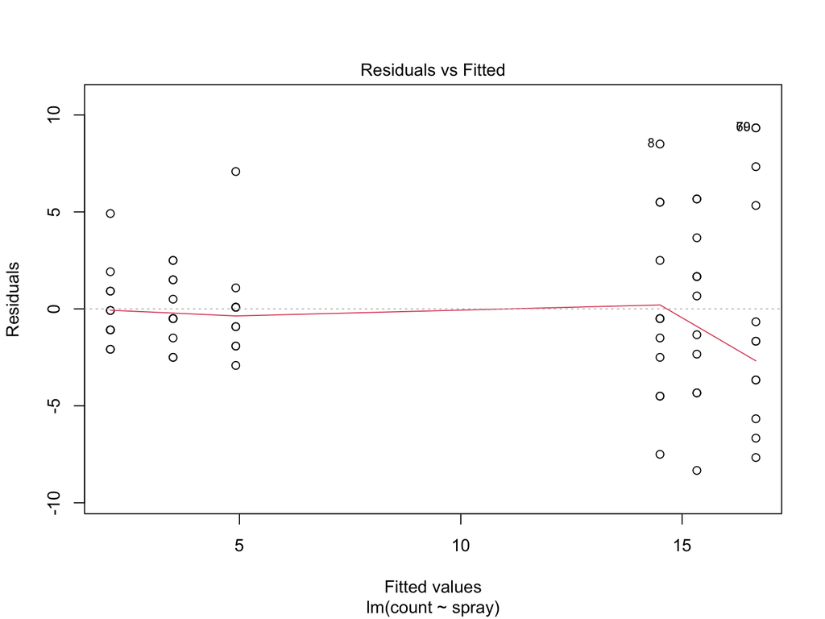

```r
plot(  spray_model, which = 1 )
```

## Plotting

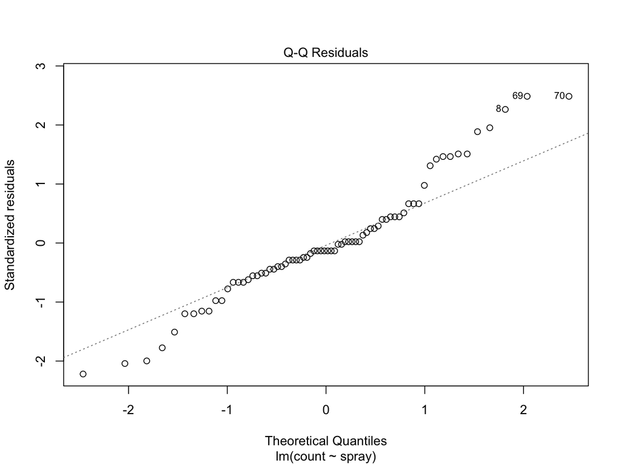

```r
plot(  spray_model, which = 2 )
```

## Example 3: `PlantGrowth` data

- Another inbuilt `R` data. It has a response variable `weight` and a categorical predictor `group` with possible levels `ctrl`, `trt1`, and `trt2`.
- The data has $n=30$ observations.
- Let’s build the ANOVA table:

## Example 3: `PlantGrowth` data

```r
data("PlantGrowth")
PlantGrowth
```

```
##    weight group
## 1    4.17  ctrl
## 2    5.58  ctrl
## 3    5.18  ctrl
## 4    6.11  ctrl
## 5    4.50  ctrl
## 6    4.61  ctrl
## 7    5.17  ctrl
## 8    4.53  ctrl
## 9    5.33  ctrl
## 10   5.14  ctrl
## 11   4.81  trt1
## 12   4.17  trt1
## 13   4.41  trt1
## 14   3.59  trt1
```

[output cut: 16 more lines]

## Example 3: `PlantGrowth` data

```r
plant_model = lm(weight ~ group, data = PlantGrowth)
summary.aov(plant_model)
```

```
##             Df Sum Sq Mean Sq F value Pr(>F)
## group        2  3.766  1.8832   4.846 0.0159 *
## Residuals   27 10.492  0.3886
## ---
## Signif. codes:  0 '***' 0.001 '**' 0.01 '*' 0.05 '.' 0.1 ' ' 1
```

## Example 3: `PlantGrowth` data

- See that since the predictor `group` has k=3 levels, the degrees of freedom = 2.
- Total degrees of freedom = 30-1 = 29.
- F = (3.7663 /2)/(10.4921/27) = 4.846.
- Reject $H_0$ that $\mu_1 = \mu_2 = \mu_3$ since $p$ value < $0.05$.

## Example 3: `PlantGrowth` data

Also, visualize the effect of the predictor `group` on response `weight`.

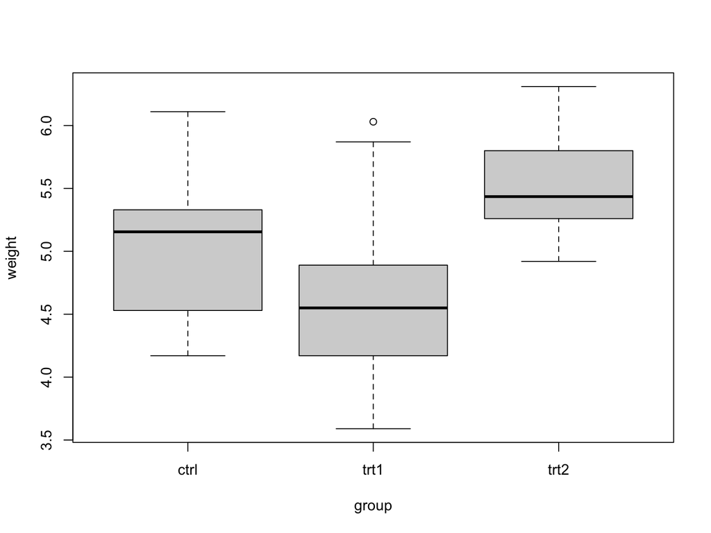

```r
boxplot(weight ~ group, data = PlantGrowth)
```

## Tukey’s Multiple Comparison

- Once your $H_0$ is rejected, you only know that at least one of your treatment effects ($\mu_i$) are different from others.
- However, you don’t know exactly which one is different, or how they behave in comparison to each other.
- The Tukey HSD (Honestly Significant Difference) helps you compare the differences between the treatment effects $\mu_i - \mu_j$.
- The $\texttt{R}$ code is `TukeyHSD(aov(<model_name>))`.

## Tukey’s Multiple Comparison: Example

- In the last example of `PlantGrowth` data, the TukeyHSD() output will show the pairwise comparisons between the groups (ctrl vs. trt1, ctrl vs. trt2, and trt1 vs. trt2).
- It will show the difference in means, confidence intervals, and adjusted p-values.

```r
TukeyHSD(aov(plant_model))
```

```
##   Tukey multiple comparisons of means
##     95% family-wise confidence level
##
## Fit: aov(formula = plant_model)
##
## $group
##             diff        lwr       upr     p adj
## trt1-ctrl -0.371 -1.0622161 0.3202161 0.3908711
## trt2-ctrl  0.494 -0.1972161 1.1852161 0.1979960
## trt2-trt1  0.865  0.1737839 1.5562161 0.0120064
```

## Pairwise t test

- Another alternate idea is to perform a pairwise t tests between a pair of effects of the treatments.
- So for example, in this data, we will perform multiple t tests for the difference between trt1 vs trt2, trt1 vs ctrl., trt2 vs. ctrl.
- Due to the multiplicity of the number of t tests, here one needs to adjust the $p$ values of the tests because it increases the likelihood of finding at least one statistically significant result purely by chance.

## Pairwise t test

- There are multiple ways to address this:
  - “none”: No adjustment.
  - “bonferroni”: Bonferroni correction. Divides the significance level by the number of tests.
  - “holm”: Holm’s method. A stepwise approach to sequentially adjusting p-values for comparisons.
  - “BH”: Benjamini-Hochberg correction.
  - “fdr”: False Discovery Rate.

## Example: pairwise t test with no correction

```r
pairwise.t.test(PlantGrowth$weight, PlantGrowth$group,
                p.adjust.method = "none")
```

```
##
##  Pairwise comparisons using t tests with pooled SD
##
## data:  PlantGrowth$weight and PlantGrowth$group
##
##      ctrl   trt1
## trt1 0.1944 -
## trt2 0.0877 0.0045
##
## P value adjustment method: none
```

## Example: pairwise t test with Bonferroni’s correction

```r
pairwise.t.test(PlantGrowth$weight, PlantGrowth$group,
                p.adjust.method = "bonferroni")
```

```
##
##  Pairwise comparisons using t tests with pooled SD
##
## data:  PlantGrowth$weight and PlantGrowth$group
##
##      ctrl  trt1
## trt1 0.583 -
## trt2 0.263 0.013
##
## P value adjustment method: bonferroni
```

## Example: pairwise t test with Holm’s correction

```r
pairwise.t.test(PlantGrowth$weight, PlantGrowth$group,
                p.adjust.method = "holm")
```

```
##
##  Pairwise comparisons using t tests with pooled SD
##
## data:  PlantGrowth$weight and PlantGrowth$group
##
##      ctrl  trt1
## trt1 0.194 -
## trt2 0.175 0.013
##
## P value adjustment method: holm
```

## Summary

- You will typically see an increase in the $p$ values when you use an adjustment.
- Different adjustment methods will lead to different increment in the p values, resulting in different type 1 and type 2 errors of the test.
- In our example, so far the results have been consistent at level $0.05$, i.e., only the `trt1 - trt2` has shown significant difference.
- There are other methods, such as Fisher’s LSD test, Dunnett’s test, etc., that will also allow you to similarly check the pairwise differences.

## Two-Way ANOVA

- Time to delve deeper.
- Up until now, we’ve worked with one response variable, $y$, and a single categorical predictor variable, $x$, with levels $1, \ldots, k$.
- Now, we’re expanding to a case with two predictor variables, $A$ and $B$.
- Predictor $A$ has $a$ levels, labeled $\alpha_1, \ldots, \alpha_a$.
- Predictor $B$ has $b$ levels, labeled $\beta_1, \ldots, \beta_b$.

## Two-way ANOVA: Example 1

- Suppose you are studying the effects of different fertilizers and sunlight levels on plant growth.
  - **Response Variable:** Plant growth (height or weight).
  - **Predictor A:** Consider 3 types of fertilizers - fertilizer 1,2, and 3.
  - **Predictor B:** Sunlight level with 2 levels — full sunlight and partial sunlight.
- A two-way ANOVA would help determine if plant growth differs significantly across fertilizer types, sunlight levels, and if there’s an interaction effect between the type of fertilizer and sunlight exposure.

## Interaction-free (or Additive) Model

- First, consider the simpler model, without the interaction term.
- This is also called the additive model/ main effects model.
- The regression model looks like the following:

$$y_{ijk} = \alpha_i + \beta_j +
\epsilon_{ijk}$$

- where $y_{ijk}$ is the $k$-th observation that is receiving the $i$-th level of predictor A (or $\alpha_i$), $j$-th level of predictor B (or $\beta_j$)
- $\epsilon_{ijk}$ error term of the model.

## ANOVA Table format

| Source | Df | Sum Sq | Mean Sq | F value |
| --- | --- | --- | --- | --- |
| Predictor A | a - 1 | *SSA* | *MSA* = $\frac{SSA}{a-1}$ | $F_A = \frac{MSA}{MSE}$ |
| Predictor B | b - 1 | *SSB* | *MSB* = $\frac{SSB}{b-1}$ | $F_B = \frac{MSB}{MSE}$ |
| Residuals | (n-1) - (a-1) - (b-1) = n-a-b+1 | *SSE* | *MSE* = $\frac{SSE}{n-a-b+1}$ |  |

## F Test For Predictor A

- $H_0$: Predictor A has no significance, or alternatively, $\alpha_1 = \alpha_2 = \ldots = \alpha_a$.
- $H_A$: At least one level of A has a different effect from the others.
- Reject $H_0$ if $F_A > F_{\alpha; a-1, n-a-b+1}$ or if the corresponding $p$ value < $\alpha$.

## F Test For Predictor B

- $H_0$: Predictor B has no significance, or alternatively, $\beta_1 = \beta_2 = \ldots = \beta_b$.
- $H_A$: At least one level of B has a different effect from the others.
- Reject $H_0$ if $F_B > F_{\alpha; b-1, n-a-b+1}$ or if the corresponding $p$ value < $\alpha$.

## Example: `warpbreaks` data

- This data set is on the number of warp breaks per loom. It has 54 observations on 3 variables.
  - `breaks`: The number of breaks
  - `wool`: Type of wool (`A` or `B`)
  - `tension`: The level of tension (`L`, `M`, `H`)
- Let’s see the boxplot of effects, build the regression model, and the ANOVA table.

## Example: `warpbreaks` data

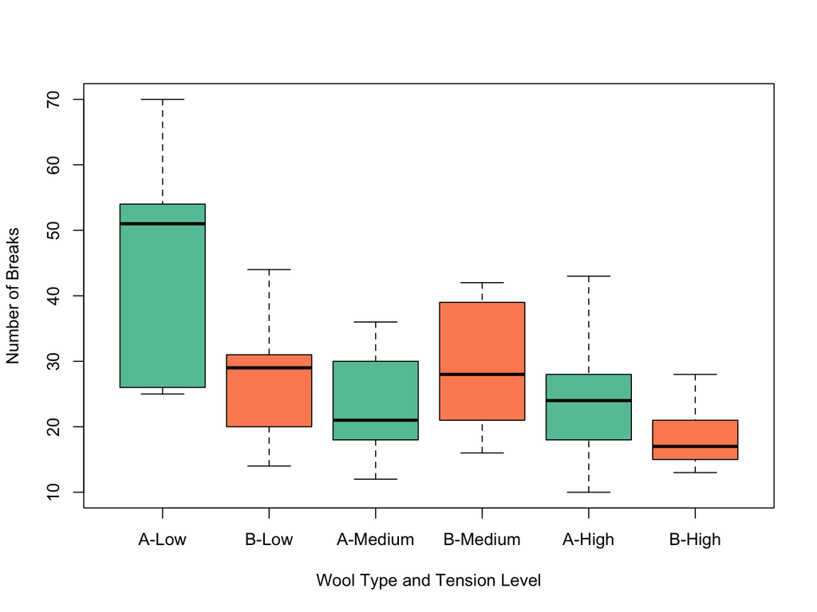

```r
boxplot(breaks ~ wool + tension, data = warpbreaks,
        col = c("#66C2A5", "#FC8D62"),
        xlab = "Wool Type and Tension Level", ylab = "Number of Breaks",
        names = c("A-Low", "B-Low", "A-Medium", "B-Medium", "A-High", "B-High"))
```

## Example: `warpbreaks` data

```r
data("warpbreaks") # No need of this line in your homework
warp_model = lm(breaks ~ wool + tension, data = warpbreaks)
summary.aov(warp_model)
```

```
##             Df Sum Sq Mean Sq F value  Pr(>F)
## wool         1    451   450.7   3.339 0.07361 .
## tension      2   2034  1017.1   7.537 0.00138 **
## Residuals   50   6748   135.0
## ---
## Signif. codes:  0 '***' 0.001 '**' 0.01 '*' 0.05 '.' 0.1 ' ' 1
```

## Test for Variable `wool`

- $H_0$: Effect of wool type A = Effect of wool type B.
- $H_A$: Effect of wool type A $\neq$ Effect of wool type B.
- Check the $p$ value (0.07) in the ANOVA table. If we are testing at level $\alpha = 0.05$, we can not reject $H_0$.
- Therefore, in this regression model, `wool` does not have a significant contribution (or effect of different levels of `wool` are not statistically different).

## Test for Variable `tension`

- $H_0$: The effect of low, medium, and high tension levels are equal.
- $H_A$: At least one tension level has a different effect from the others.
- Check the $p$ value (0.001) in the ANOVA table. We can reject $H_0$.
- Therefore, in this regression model, `tension` has a significant effect in the model, suggesting that at least one level of `tension` differs significantly from the others in terms of affecting the response.

## Postdoc Testing/ Multiple Comparison

- Let’s try the Tukey’s HSD test first to see which `tension` levels are statistically different.

```r
TukeyHSD( aov(warp_model)  )
```

```
##   Tukey multiple comparisons of means
##     95% family-wise confidence level
##
## Fit: aov(formula = warp_model)
##
## $wool
##          diff       lwr       upr     p adj
## B-A -5.777778 -12.12841 0.5728505 0.0736137
##
## $tension
##           diff       lwr        upr     p adj
## M-L -10.000000 -19.35342 -0.6465793 0.0336262
## H-L -14.722222 -24.07564 -5.3688015 0.0011218
## H-M  -4.722222 -14.07564  4.6311985 0.4474210
```

## Tukey’s Test

- See that the 95% confidence interval for `wool` contains 0. Alternatively, the $p$ value is high (> 0.05). Hence, `wool` is insignificant, or no difference between the 2 levels of `wool`.
- For `tension`, the 95% CI of M-L (medium - low) and H-L are always negative. Hence, these two levels are statistically different.
- You can also look at the $p$ values and figure out which one is different. Remember, $p$ < $\alpha$ implies statistically different from $0$.

## Interaction Model

- In usual real-world cases, the combined effect of two predictors A and B is not simply additive, but depends on the specific levels of each factor.
- The interaction model helps us to quantify these dependency effects.
- Example: Consider a study on the effects of a new drug and diet-type on blood pressure. Here,
  - Predictor A: **Medication** with two levels — “drug” and “placebo”.
  - Predictor B: **Diet** with two levels — “low-sodium” and “regular”.

## Interaction Model

- **If there is no interaction:** We would expect that each predictor has an additive, independent effect on blood pressure.
  - For instance, if the medication reduces blood pressure by 10 units and the low-sodium diet reduces it by 5 units, using both might result in a reduction of 15 units.

## Interaction Model

- **If there is an interaction:** The effect of the medication could depend on the type of diet. For example:
  - With a regular diet, the medication might reduce blood pressure by 10 units.
  - However, with a low-sodium diet, the medication could work much better and reduce blood pressure by 20 units instead of the expected 15 units.

## Regression Model with Interaction

- The regression model with interaction looks like the following:

$$y_{ijk} = \alpha_i + \beta_j + (\alpha
\beta)_{ij} + \epsilon_{ijk}$$

## ANOVA Table format

| Source | Df | Sum Sq | Mean Sq | F value |
| --- | --- | --- | --- | --- |
| Predictor A | a - 1 | *SSA* | *MSA* = $\frac{SSA}{a-1}$ | $F_A = \frac{MSA}{MSE}$ |
| Predictor B | b - 1 | *SSB* | *MSB* = $\frac{SSB}{b-1}$ | $F_B = \frac{MSB}{MSE}$ |
| Interaction | (a-1)(b-1) | *SSAB* | *MSAB* = $\frac{SSAB}{(a-1)(b-1)}$ | $F_{AB} = \frac{MSAB}{MSE}$ |
| Residuals | n- a b | *SSE* | *MSE* = $\frac{SSE}{n- ab}$ |  |

## F test for Interaction

- You can do the main effects test (for A and B) similarly.
- To test the interaction, we use the following:
  - $H_0$: No interaction effect or $(\alpha \beta)_{ij}$ = 0 for all i and j.
  - $H_A$: At least one of them is non-zero or there is some interaction effect.
- Reject $H_0$ if F > $F_{\alpha; (a-1)(b-1), n -ab}$ or if the corresponding p value < $\alpha$.

## Example: `warpbreaks` data with interaction term

```r
data("warpbreaks") # No need of this line in your homework
warp_model = lm(breaks ~ wool + tension + wool:tension , data = warpbreaks)
summary.aov(warp_model)
```

```
##              Df Sum Sq Mean Sq F value   Pr(>F)
## wool          1    451   450.7   3.765 0.058213 .
## tension       2   2034  1017.1   8.498 0.000693 ***
## wool:tension  2   1003   501.4   4.189 0.021044 *
## Residuals    48   5745   119.7
## ---
## Signif. codes:  0 '***' 0.001 '**' 0.01 '*' 0.05 '.' 0.1 ' ' 1
```

## Tukey’s Test

```r
TukeyHSD( aov(warp_model) )
```

```
##   Tukey multiple comparisons of means
##     95% family-wise confidence level
##
## Fit: aov(formula = warp_model)
##
## $wool
##          diff       lwr       upr    p adj
## B-A -5.777778 -11.76458 0.2090243 0.058213
##
## $tension
##           diff       lwr       upr     p adj
## M-L -10.000000 -18.81965 -1.180353 0.0228554
## H-L -14.722222 -23.54187 -5.902575 0.0005595
## H-M  -4.722222 -13.54187  4.097425 0.4049442
##
## $`wool:tension`
##                diff       lwr        upr     p adj
## B:L-A:L -16.3333333 -31.63966  -1.027012 0.0302143
## A:M-A:L -20.5555556 -35.86188  -5.249234 0.0029580
## B:M-A:L -15.7777778 -31.08410  -0.471456 0.0398172
## A:H-A:L -20.0000000 -35.30632  -4.693678 0.0040955
## B:H-A:L -25.7777778 -41.08410 -10.471456 0.0001136
## A:M-B:L  -4.2222222 -19.52854  11.084100 0.9626541
## B:M-B:L   0.5555556 -14.75077  15.861877 0.9999978
## A:H-B:L  -3.6666667 -18.97299  11.639655 0.9797123
## B:H-B:L  -9.4444444 -24.75077   5.861877 0.4560950
## B:M-A:M   4.7777778 -10.52854  20.084100 0.9377205
## A:H-A:M   0.5555556 -14.75077  15.861877 0.9999978
## B:H-A:M  -5.2222222 -20.52854  10.084100 0.9114780
## A:H-B:M  -4.2222222 -19.52854  11.084100 0.9626541
## B:H-B:M -10.0000000 -25.30632   5.306322 0.3918767
## B:H-A:H  -5.7777778 -21.08410   9.528544 0.8705572
```

## Summary

- In ANOVA, the primary goal is to test the impact of various levels of a categorical predictor on a response variable.
- We aim to identify differences in effects across these levels. Differnt effects means significant predictor.
- The F-test begins with the hypothesis that there is no difference in effects among the levels.
- If the F-test indicates a significant result, post hoc tests can be performed to conduct pairwise comparisons.
- In two-way ANOVA models, interaction terms are often essential because the effect of one factor may vary across the levels of another factor.